# Filas

Considere um problema básico de filas em que as chegadas ocorrem segundo uma distribuição exponencial de parâmetro λ1 e os atendimentos segundo segundo uma distribuição exponencial de parâmetro λ2. Supõe-se independência entre as chegadas e atendimentos.

Diferentes cenários podem ser definidos com escolhas de tempo/tamanho da fila, λ1 e λ2.

- 1.Forneça um código para geração das filas e ilustre o uso em diferentes cenários.
- 2.Estude a distribuição amostral do tamanho mediano da fila.
- 3.Estude a distribuição amostral do tamanho máximo da fila.

………………………………………………………………………………………………………………………………………………………….

### Resolução

- Chegadas:

O tempo entre as chegadas de clientes em um sistema de filas é modelado por uma distribuição exponencial, cuja função densidade de probabilidade (PDF) é dada por:

$$f(t_c) = \lambda e^{-\lambda t_c}, \quad t_c \geq 0$$

- $\lambda$ → taxa média de chegadas por **minuto**
- $t_c$ → tempo (em minutos) até a próxima chegada

```r
lambda <- 5/60 # taxa média de chegada convertida em minutos (5/hora)

rexp(1, rate = lambda)
```

```
[1] 16.80661
```

O tempo de atendimento de cada cliente em um sistema de filas é modelado por uma distribuição exponencial, cuja função densidade de probabilidade (PDF) é:

$$f(t_a) = \lambda_2 e^{-\lambda_2 t_a}, \quad t_a \geq 0$$

- $\lambda_2$ → taxa média de atendimentos por unidade de tempo (por exemplo, por minuto ou por hora)
- $t_a$ → tempo de atendimento de um cliente

```r
lambda2 <- 5/60 # taxa média de atendimento convertida em minutos (5/hora)

rexp(1, rate = lambda2)
```

```
[1] 4.891243
```

Dado que as chegadas independem do tempo de atendimento, podemos gerar a simulação de um dia de expediente com os períodos de chegada

```r
tempo_total <- 0
chegadas <- c()

tempo_limite <- 600 # 10horas de expediente



while (tempo_total < tempo_limite) {
  tempo_proxima_chegada <- rexp(1, rate = lambda)
  tempo_total <- tempo_total + tempo_proxima_chegada
  if (tempo_total <= tempo_limite) {
    chegadas <- c(chegadas, tempo_total)
  }
}
chegadas
```

```
 [1]  10.31266  24.77669  49.23862  49.34343  71.21469  76.63106  98.29060 102.14489 107.53487 124.73457 145.96489 155.01715
[13] 155.02696 159.03907 160.71390 161.90409 165.70593 176.08464 189.03005 212.22313 225.77137 238.83896 248.87170 255.37205
[25] 261.57265 278.69269 288.25441 288.25884 312.84646 320.01516 336.34470 338.21459 346.67042 396.86760 402.96255 410.73994
[37] 420.82810 456.73508 462.57389 476.47867 478.76843 494.45053 494.67272 499.29811 508.73400 531.72110 577.50474
```

```r
(Total_chegadas <- length(chegadas))
```

```
[1] 47
```

Definido a quantidade de pessoas que chegaram, podemos gerar agora o tempo de cada atendimento

```r
(tempo_atendimento <- rexp(Total_chegadas, rate = lambda2))
```

```
 [1]  6.06716040 25.18067693  0.12169863 51.37826539  8.62401780 12.64360509 18.55982087  0.68520359  8.74162868 18.24815163
[11]  9.82335355  2.00861398 40.01785415  3.89304963 33.14649065  9.69768866  0.37300944 17.29065388  7.67465927  1.10355530
[21] 16.65647043 10.90838491  1.53220034 14.03923993  2.38620759 35.10629940 10.59406969 29.82103238  2.69303160 38.18503600
[31]  1.06343137  2.40882025  9.20218044  8.07445130 31.06165912 12.45163728  2.06202141 14.24826667  6.01363006  0.01223608
[41] 11.18568764 23.62919325  7.88790144 20.11169267 29.30226157  1.01492405 30.34290659
```

como definir a fila ?

```r
#Início - atendimento 1
atendimentos_feitos <- 0
fila_atual <- 0

fim_atendimento <-  numeric(Total_chegadas)


(inicio_atendimento <- chegadas[1])
```

```
[1] 10.31266
```

```r
(tempo_atendimento[1])
```

```
[1] 6.06716
```

```r
(fim_atendimento[1] <- inicio_atendimento + tempo_atendimento[1])
```

```
[1] 16.37982
```

```r
#Atendimento 2

chegadas[2]
```

```
[1] 24.77669
```

```r
(atendimentos_feitos <- sum(fim_atendimento <= chegadas[2] & fim_atendimento > 0))
```

```
[1] 1
```

```r
(fila_atual <- 1 - atendimentos_feitos)
```

```
[1] 0
```

```r
(inicio_atendimento <- max(max(fim_atendimento) ,chegadas[2]))
```

```
[1] 24.77669
```

```r
(tempo_atendimento[2])
```

```
[1] 25.18068
```

```r
(fim_atendimento[2] <- inicio_atendimento + tempo_atendimento[2])
```

```
[1] 49.95737
```

```r
#Atendimento 3

chegadas[3]
```

```
[1] 49.23862
```

```r
(atendimentos_feitos <- sum(fim_atendimento <= chegadas[3] & fim_atendimento > 0))
```

```
[1] 1
```

```r
(fila_atual <- 2 - atendimentos_feitos)
```

```
[1] 1
```

```r
(inicio_atendimento <- max(max(fim_atendimento) ,chegadas[3]))
```

```
[1] 49.95737
```

```r
(tempo_atendimento[3])
```

```
[1] 0.1216986
```

```r
(fim_atendimento[3] <- inicio_atendimento + tempo_atendimento[3])
```

```
[1] 50.07907
```

```r
fim_atendimento
```

```
 [1] 16.37982 49.95737 50.07907  0.00000  0.00000  0.00000  0.00000  0.00000  0.00000  0.00000  0.00000  0.00000  0.00000
[14]  0.00000  0.00000  0.00000  0.00000  0.00000  0.00000  0.00000  0.00000  0.00000  0.00000  0.00000  0.00000  0.00000
[27]  0.00000  0.00000  0.00000  0.00000  0.00000  0.00000  0.00000  0.00000  0.00000  0.00000  0.00000  0.00000  0.00000
[40]  0.00000  0.00000  0.00000  0.00000  0.00000  0.00000  0.00000  0.00000
```

```r
sim_fila <- function(lambda_chegada, lambda_atendimento, tempo_expediente){

  tempo_total <- 0
  chegadas <- c()



  #Gerar chegadas em um dia de expediente
  while (tempo_total < tempo_expediente) {
    tempo_proxima_chegada <- rexp(1, rate = lambda_chegada)
    tempo_total <- tempo_total + tempo_proxima_chegada
    if (tempo_total <= tempo_expediente) {
      chegadas <- c(chegadas, tempo_total)
    }
  }

  #Total de chegadas no dia
  Total_chegadas <- length(chegadas)


  #Gerar tempo de atendimento para cada chegada
  tempo_atendimento <- rexp(Total_chegadas, rate = lambda_atendimento)

  #Primeiro atendimento

  inicio_atendimento <-  numeric(Total_chegadas)
  fim_atendimento <-  numeric(Total_chegadas)
  fila_atual <-  numeric(Total_chegadas)




  inicio_atendimento[1] <- chegadas[1]

  atendimentos_feitos <- 0
  fila_atual[1] <- 0

  fim_atendimento[1] <- inicio_atendimento[1] + tempo_atendimento[1]

  for (i in 2:Total_chegadas){


    atendimentos_feitos <- sum(fim_atendimento <= chegadas[i] & fim_atendimento > 0)

    fila_atual[i] <- (i-1) - atendimentos_feitos

    inicio_atendimento[i] <- max(max(fim_atendimento) ,chegadas[i])

    fim_atendimento[i] <- inicio_atendimento[i] + tempo_atendimento[i]


  }

  return (fila_atual)

}
```

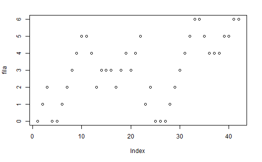

```r
fila <- sim_fila(5/60,4/60,600)


plot(fila)
```

#### 1.Forneça um código para geração das filas e ilustre o uso em diferentes cenários.

```r
atend_menor <-  sim_fila(lambda_chegada = 5/60,
                         lambda_atendimento = 3/60,
                          tempo_expediente = 600)


atend_igual <-  sim_fila(lambda_chegada = 5/60,
                         lambda_atendimento = 5/60,
                          tempo_expediente = 600)


atend_maior <-  sim_fila(lambda_chegada = 5/60,
                         lambda_atendimento = 7/60,
                          tempo_expediente = 600)


plot(atend_menor, type = "l", col = "red", lwd = 2,
     xlab = "Ordem de chegada", ylab = "Tamanho da fila",
     main = "Comparativo de Tamanho da Fila em Diferentes Cenários",
     ylim = range(c(atend_menor, atend_igual, atend_maior)))  # para ajustar o eixo y

# Adicionar as outras duas linhas no mesmo gráfico
lines(atend_igual, col = "blue", lwd = 2)
```

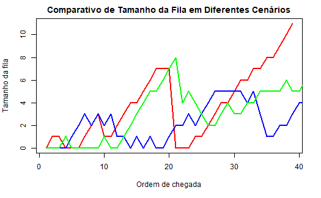

```r
lines(atend_maior, col = "green", lwd = 2)
```

```r
NA
NA
NA
```